# Practical Machine Learning PA

Jakub Winter aka Rawrqs on GitHub

Friday, August 22, 2014

## Summary

In this project, the goal was to use data from accelerometers on the belt, forearm, arm, and dumbell of 6 participants. They were asked to perform barbell lifts correctly and incorrectly in 5 different ways. The goal of your project was to predict the manner in which they did the exercise. This is the “classe” variable in the training set. For this purpose i have used the random forest technique while using two approaches. After using the first approach for predicting test cases from coursera i have classified correctly all of the cases and the accuracy for my testing set was over 99%.

## Cleaning the data

### Data selection

```r
data <- read.csv("C:/Users/Kuba/Desktop/pml-training.csv", header=TRUE, sep=",", na.strings= c("NA", ""))
choose <- c(2, 8:11, 37:49, 60:68, 84:86, 102, 113:124, 140, 151:159, 160)
#removing all rows that are summaries
data.2 <- data[data$new_window == "no",]
#creating only data with parameters of interest
data.3 <- data[, choose]
colnames(data.3)
```

```
 [1] "user_name"            "roll_belt"            "pitch_belt"
 [4] "yaw_belt"             "total_accel_belt"     "gyros_belt_x"
 [7] "gyros_belt_y"         "gyros_belt_z"         "accel_belt_x"
[10] "accel_belt_y"         "accel_belt_z"         "magnet_belt_x"
[13] "magnet_belt_y"        "magnet_belt_z"        "roll_arm"
[16] "pitch_arm"            "yaw_arm"              "total_accel_arm"
[19] "gyros_arm_x"          "gyros_arm_y"          "gyros_arm_z"
[22] "accel_arm_x"          "accel_arm_y"          "accel_arm_z"
[25] "magnet_arm_x"         "magnet_arm_y"         "magnet_arm_z"
[28] "roll_dumbbell"        "pitch_dumbbell"       "yaw_dumbbell"
[31] "total_accel_dumbbell" "gyros_dumbbell_x"     "gyros_dumbbell_y"
[34] "gyros_dumbbell_z"     "accel_dumbbell_x"     "accel_dumbbell_y"
[37] "accel_dumbbell_z"     "magnet_dumbbell_x"    "magnet_dumbbell_y"
[40] "magnet_dumbbell_z"    "roll_forearm"         "pitch_forearm"
[43] "yaw_forearm"          "total_accel_forearm"  "gyros_forearm_x"
[46] "gyros_forearm_y"      "gyros_forearm_z"      "accel_forearm_x"
[49] "accel_forearm_y"      "accel_forearm_z"      "magnet_forearm_x"
[52] "magnet_forearm_y"     "magnet_forearm_z"     "classe"
```

After doing the abovementioned there were no more NA’s in data.

```r
any(is.na(data.3)==TRUE)
```

```
[1] FALSE
```

## Random forest

I have choosen to use random forest for my modelling, therefore there was no need for creating part of data for cross validation. I decided to split the data into training and testing set by the ratio of 0.7 training set, and 0.3 test set using default sampling options from the createDataPartition in the caret package. I expect the out of sample error to be rather small, as the rf does not overfitt and has some nice algorith foraveraging the predictors.

```r
library(caret)
#?createDataPartition
inTrain <- createDataPartition(data.3$classe, p = 0.7, list = FALSE)
training = data.3[inTrain,]
testing = data.3[-inTrain,]
```

I have decided to do two approaches:

- First - to fit a model for every participant with a dependend variable name using all possible information to learn the model
- Secound - to fit a model for every participant separately, which would catch thier specific characteristics of human body

```r
library(doParallel)
registerDoParallel(4)
library(e1071)
fit <- train(classe ~., data = training, method = "rf")
fit.adelmo <- train(classe ~., data = subset(training, user_name == "adelmo")[,-1], method = "rf")
fit.carlitos <- train(classe ~., data = subset(training, user_name == "carlitos")[,-1], method = "rf")
fit.charles <- train(classe ~., data = subset(training, user_name == "charles")[,-1], method = "rf")
fit.eurico <- train(classe ~., data = subset(training, user_name == "eurico")[,-1], method = "rf")
fit.jeremy <- train(classe ~., data = subset(training, user_name == "jeremy")[,-1], method = "rf")
fit.pedro <- train(classe ~., data = subset(training, user_name == "pedro")[,-1], method = "rf")
```

## Variable importance

The plot below presents normalized variable importance for the first apprach. We can see that roll_belt was the most important variable while classyfing to the group. We can see that user_name may not be found in the top 20 variables

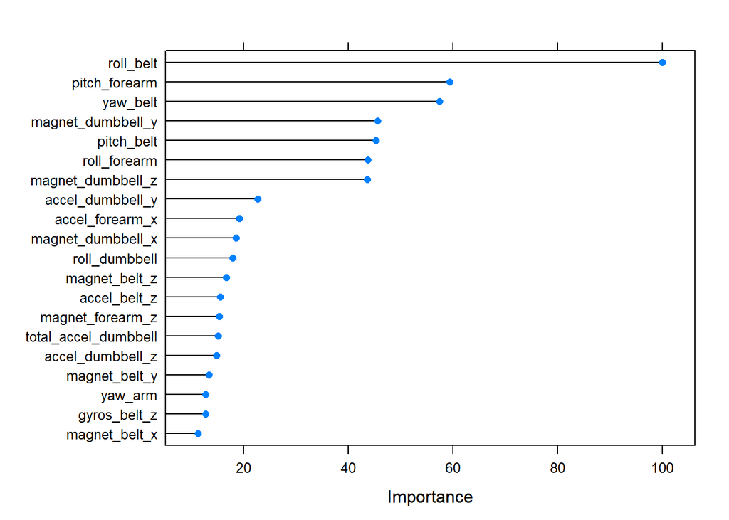

```r
plot(varImp(fit), top = 20)
```

## Confusion Matrix for approach 1

```r
confusionMatrix(predict(fit,newdata=testing[,-ncol(testing)]),testing$classe)
```

```
Confusion Matrix and Statistics

          Reference
Prediction    A    B    C    D    E
         A 1672    9    0    0    0
         B    2 1126    6    0    0
         C    0    4 1016   14    1
         D    0    0    4  947    3
         E    0    0    0    3 1078

Overall Statistics

               Accuracy : 0.992
                 95% CI : (0.99, 0.994)
    No Information Rate : 0.284
    P-Value [Acc > NIR] : <2e-16

                  Kappa : 0.99
 Mcnemar's Test P-Value : NA

Statistics by Class:

                     Class: A Class: B Class: C Class: D Class: E
Sensitivity             0.999    0.989    0.990    0.982    0.996
Specificity             0.998    0.998    0.996    0.999    0.999
Pos Pred Value          0.995    0.993    0.982    0.993    0.997
Neg Pred Value          1.000    0.997    0.998    0.997    0.999
Prevalence              0.284    0.194    0.174    0.164    0.184
Detection Rate          0.284    0.191    0.173    0.161    0.183
Detection Prevalence    0.286    0.193    0.176    0.162    0.184
Balanced Accuracy       0.998    0.993    0.993    0.990    0.998
```

```r
w.1 <- nrow(subset(testing, user_name == "adelmo"))
o.1 <- confusionMatrix(predict(fit.adelmo,newdata=subset(testing[,-ncol(testing)], user_name == "adelmo")[,-1]),subset(testing, user_name == "adelmo")$classe)[[3]][1]

o.2 <- confusionMatrix(predict(fit.carlitos,newdata=subset(testing[,-ncol(testing)], user_name == "carlitos")[,-1]),subset(testing, user_name == "carlitos")$classe)[[3]][1]
w.2 <- nrow(subset(testing, user_name == "carlitos"))

o.3 <- confusionMatrix(predict(fit.charles,newdata=subset(testing[,-ncol(testing)], user_name == "charles")[,-1]),subset(testing, user_name == "charles")$classe)[[3]][1]
w.3 <- nrow(subset(testing, user_name == "charles"))

o.4 <- confusionMatrix(predict(fit.eurico,newdata=subset(testing[,-ncol(testing)], user_name == "eurico")[,-1]),subset(testing, user_name == "eurico")$classe)[[3]][1]
w.4 <- nrow(subset(testing, user_name == "eurico"))

o.5 <- confusionMatrix(predict(fit.jeremy,newdata=subset(testing[,-ncol(testing)], user_name == "jeremy")[,-1]),subset(testing, user_name == "jeremy")$classe)[[3]][1]
w.5 <- nrow(subset(testing, user_name == "jeremy"))

o.6 <- confusionMatrix(predict(fit.pedro,newdata=subset(testing[,-ncol(testing)], user_name == "pedro")[,-1]),subset(testing, user_name == "pedro")$classe)[[3]][1]
w.6 <- nrow(subset(testing, user_name == "pedro"))
```

## Predicting the testing data set from Coursera

The secound part of assignment assumes predicting set of 20 observations. The predictions from my first model are as follows:

```r
data.answers <- read.csv("C:/Users/Kuba/Desktop/pml-testing.csv", header=TRUE, sep=",", na.strings= c("NA", ""))

answers <- predict(fit,data.answers)
print(answers)
```

```
 [1] B A B A A E D B A A B C B A E E A B B B
Levels: A B C D E
```

## Anwers for the secound part of assigment

Below is a code that generates anwers for the secound part of the assignment.

```r
pml_write_files = function(x){
  n = length(x)
  for(i in 1:n){
    filename = paste0("problem_id_",i,".txt")
    write.table(x[i],file=filename,quote=FALSE,row.names=FALSE,col.names=FALSE)
  }
}

pml_write_files(answers)
```